# Day 1 - Introduction

03/05/2018

## PA: Applied Time Series Forecasting

## About Myself

### Klaus C. Langenheldt

- Education
  - MSc Information Systems (Data Science)
  - Industrial PhD Data Science
- Work
  - Software Engineer @ Danish Bank
  - AI Researcher @ Blackwood Seven
- Focus Areas
  - Time Series Forecasting
  - Supervised Machine Learning
  - Media Mix Modelling

## What will this Course be About?

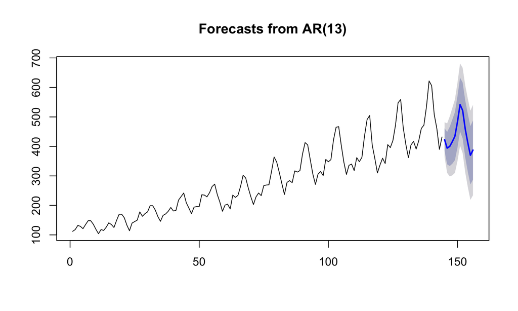

Monthly Airline Passenger Numbers 1949-1960 (in thousands)

## Prediction is Difficult

**'Prediction is very difficult, especially about the future.'**

- Niels Bohr (Nobel Prize for Physics in 1922, Quantum Physics)

## Valuableness of TS Forecasting

- Demand forecasting (inventory optimisation)
- Pattern recognition (anomaly detection)
- Planning & Goal setting (target metric specification)
- Weather prediction (crop yield optimisation)
- Load forecasting (server load balancing)
- …

## Learning Objectives

- In this course, you will learn TS forecasting such that you
  - understand the immense value of forecasting for businesses
  - grasp the limits of forecasting
  - evaluate forecasts done inside your organisation
  - can easily create a forecasting model yourself (with YOUR business data)
  - cannot longer be fooled by your data scientists

## Content

- You will learn about
  - standard definitions of time series, time series analysis, and time series forecasting
  - important components to consider in time series data
  - most common, traditional forecasting methods
  - modern, cutting-edge hyper-automated forecasting methods
  - model evaluation
  - using external data

## Timeline

- Day 1
  - Time Series Basics
  - Computer Setup / R Environment
  - Traditional Forecasting Methods
- Day 2
  - Cutting-Edge Forecasting Methods
  - Evaluating Forecasts
  - Using External Data
  - Case Introduction

## Computer Requirements

Prerequisites:

- [R 3.0.1+](https://cran.rstudio.com)
- [R Studio](https://www.rstudio.com/products/rstudio/download/)
- Relevant libraries

  ```r
  install.packages("prophet")
  install.packages("forecast")
  install.packages("fpp")
  install.packages("dplyr")
  ```

- Material https://github.com/l4u532/cbs-forecasting

## Why R?

- [Extensive Discussion on R vs. Python](https://www.quora.com/Which-is-better-for-data-analysis-R-or-Python-Is-R-still-a-better-data-analysis-language-than-Python-Has-anyone-else-used-Python-with-Pandas-to-a-large-extent-in-data-analysis-projects)
- R is the go-to software for statistics and timeseries forecasting
- Python for general purpose programming and Machine Learning
- Exposure to both programming languages is indespensible
- It looks good on your CV

## What is a Time Series?

*A time series is a sequence of **observations** taken sequentially in **time**.* (p. 1, Time Series Analysis: Forecasting and Control)

| Date | Price |
| --- | --- |
| 2018-04-03 | 40.490002 |
| 2018-04-04 | 40.18 |
| 2018-04-05 | 40.650002 |
| 2018-04-06 | 40.209999 |
| 2018-04-07 | 40.240002 |
| 2018-04-08 | 41.849998 |

## What is a Time Series?

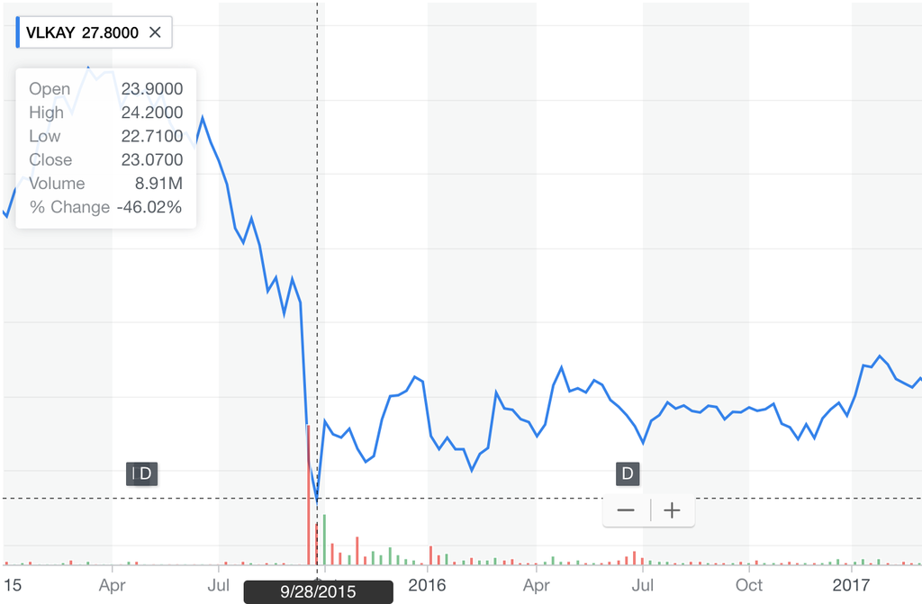

## Describing vs Predicting

- **Analysis**: seeks to understand the *why*, the *causalities* \[Y = C + I + G + (X-M)\]
- **Forecasting**: find recurring patterns and extrapolate them to the future \[Y_{t+1} = f(Y_{t_{\leq 0}})\]

(\(Y\) = national income, \(C\) = domestic household consumption, \(I\) = domestic investments, \(G\) = gov spend on goods/services, \(X-M\) = exports - imports)

## Components of a Time Series

- **Level** The baseline value for the series
- **Trend** The linear increasing or decreasing behavior over time
- **Seasonality** The repeating patterns/cycles over time
- **Noise/Residuals/Remainder** The variability that cannot be explained by the above

## Components of a Time Series

\[Y = level + trend + seasonality + noise\]

## Components of a Time Series: R Code

```r
library(forecast)
data = AirPassengers # change this line to provide new data
model <- stl(data, t.window=15, s.window="periodic", robust=TRUE)
plot(model)
```

## Data Obstacles

- **Granularity** You have daily data, but want weekly/monthly/yearly forecasts.
- **Outliers** Perhaps there are corrupt or extreme outlier values that need to be identified and handled.
- **Missing Data** Perhaps there are gaps or missing data that need to be interpolated or imputed.
- **Intermittent Data** Temporary out-of-stock periods or sporadic activity.

## Computer Setup

## Required Software

- Install [R 3.0.1+](https://cran.rstudio.com)
- Install [R Studio](https://www.rstudio.com/products/rstudio/download/)
- Install relevant R libraries [See Tutorial for Help](https://www.youtube.com/watch?v=u1r5XTqrCTQ)

  ```r
  install.packages("prophet")
  install.packages("forecast")
  install.packages("fpp")
  install.packages("dplyr")
  ```

- Download course material https://github.com/l4u532/cbs-forecasting

## Practical Challenge

## The R Studio Environment

[figure not shown]

## Decompose and Interpret a Time Series

- Copy the code from **slide #17**
- Change the data input

  ```r
  data = mdeaths
  ```

- Decompose (find components) of the time series
- Interpret the decomposition, see [UK Lung Deaths Dataset](https://www.rdocumentation.org/packages/datasets/versions/3.4.3/topics/UKLungDeaths)

## Solution

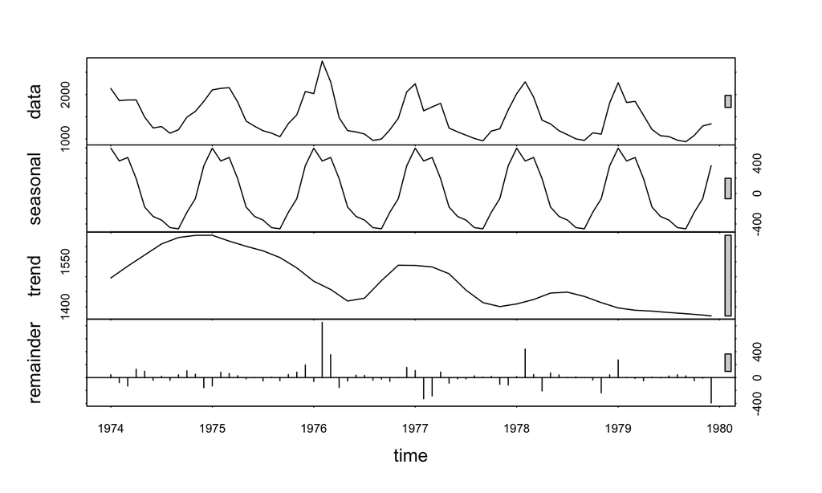

```r
library(forecast)
data = mdeaths # change this line to provide new data
model = stl(data, t.window=15, s.window="periodic", robust=TRUE)
plot(model)
```

## R Studio Tips

- The development environment's four building blocks
  - Script/Programming
  - Console
  - Environment/Variables
  - Plots, Files, etc.
- Code Execution
  - **Select** the code you want to execute
  - Press `CMD+Enter` (Mac) or `CTRL+Enter` (Windows)
  - Or Press `Run`

## Recap

## Recap

- How can time series forecasting create value for businesses?
- What are the four components of are time series?
- What are four building blocks of the R Studio development environment?